# Introduction

RNA sequencing (RNA-seq) has been utilized as the standard technology for measuring the expression abundance of genes, transcripts, exons or splicing junctions. Numerous quantification methods were proposed to quantify such abundances with combination of some RNA-seq read aligner. Unfortunately, it is currently difficult to evaluate the performance of the best method, due in part to the high costs of running assessment experiments as well as the computational requirements of running these algorithms. We have developed a series of statistical summaries and data visualization techniques to evaluate the performance of transcript quantification, particularly specificity and sensitivity.

The `rnaseqcomp` R-package performs comparisons and provides direct plots on these statistical summaries. It requires the inputs as an quantification table (or two, depending on which statistical comparisons is performed) by compared pipelines on a pair of RNA-seq samples. With necessary meta information on these pipelines (*e.g.* names), a two step analysis will generate the desired evaluations.

1. Data filtering and data preparation. In this step, options are provided for any filtering and calibration operations on the raw data. A S4 class `rnaseqcomp` object will be generated form next step.
2. Statistical summary evaluation and visualization. Functions are provided for specificity and sensitivity evaluations.

# Getting Started

Load the package in R

```r
library(rnaseqcomp)
```

# Preparing Data

As the benchmark evaluation is performed on a pair of RNA-seq replicates, a quantification table should contain \(2n\) columns (\(n\) corresponding to the number of pipeline compared), with each column representing a sample and each row representing a feature (*i.e.* genes, transcripts, exons, splicing junctions, etc.). The function `matrixFilter` takes this table as one of the inputs, with extra options such as meta information of pipelines, features for evaluation and features for calibration, and returns a S4 `rnaseqcomp` object that contains everything for downstream evaluation.

There are several reasons why we need extra options in this step:

1. Meta information of pipelines basically is a factor to check the sanity of table columns, and to provide unique names of pipelines for downstream analysis.
2. Since there might be dramatic quantification difference between different features, *e.g.* between protein coding genes and lincRNA genes, evaluations based on a subset of features can provide stronger robustness than using all involved features. Thus, an option is offered for selecting subset of features.
3. Due to different pipelines reports different units of quantification, such as FPKM (fragments per kilobases per million), RPKM (reads per kilobases per million), TPM (transcripts per million) etc. Calibrations across different units are necessary. Options are provided in the way that on which features the calibrations are based and to what pipeline the signals are mapped.

We show here an example of selecting house-keeping genes[@eisenberg] for calibration and filtering protein coding genes for evaluation. In this vignette, we will use enbedded dataset `encodeCells` as examples to illustrate this package. This dataset contains two cell-line quantifications, GM12878 and K562, each with two PolyA dUTP technical replicates by ENCODE project [(https://www.encodeproject.org)](https://www.encodeproject.org). In total, quantifications from 9 pipelines are included. Here, 9 pipelines are made up with 6 quantification methods (RESM[@li], Cufflinks[@trapnell], FluxCapacitor[@montgomery], Sailfish[@patro], eXpress[@roberts] and Naive) in conjunction to 2 mapping algorithms (STAR[@dobin] and TopHat2[@kim]) and different tuning parameters.

```r
# load the dataset in this package
data(encodeCells)
class(encodeCells)
```

```
## [1] "list"
```

```r
names(encodeCells)
```

```
## [1] "gm12878"  "k562"     "repInfo"  "genemeta" "arrayFC"
```

Here, `gm12878` and `k562` are both quantification tables; repInfo is the meta information of pipelines; `genemeta` is the meta information for features: gene type and if house-keeping gene; arrayFC is fold change information between GM12878 and K562 cell lines from microarray platform[@ernst].

In order to fit into function 'matrixFilter', necessary transformation to logical vectors are needed for extra options.

```r
evaluationFeature <- encodeCells$genemeta$type == "protein_coding"
calibrationFeature <- encodeCells$genemeta$housekeeping
unitReference <- grepl("Cufflinks",encodeCells$repInfo)
```

Generic function `show` is provided for bird-eye view of S4 `rnaseqcomp` object.

```r
dat1 <- matrixFilter(encodeCells$gm12878,encodeCells$repInfo,
    evaluationFeature,calibrationFeature,unitReference)
class(dat1)
```

```
## [1] "rnaseqcomp"
## attr(,"package")
## [1] "rnaseqcomp"
```

```r
show(dat1)
## rnaseqcomp: Benchmark for RNA-seq quantification pipelines
##
## Reps:
##  RSEM_Bowtie_TPM RSEM_Bowtie_TPM RSEM_Bowtie_pmeTPM RSEM_Bowtie_pmeTPM RSEM_STAR_TPM RSEM_STAR_TPM Cufflinks_STAR_FPKM Cufflinks_STAR_FPKM Cufflinks_TopHat_FPKM Cufflinks_TopHat_FPKM FluxCapacitor_TopHat_RPKM FluxCapacitor_TopHat_RPKM Sailfish_RPKM Sailfish_RPKM eXpress_Bowtie_RPKM eXpress_Bowtie_RPKM Naive_TopHat_RPKM Naive_TopHat_RPKM
##
## Calibration subset log2Median:
##  5.155628 5.168121 5.164102 5.170526 5.012122 5.030115 4.472787 4.540077 4.631066 4.668635 5.196811 5.155786 5.181636 5.097898 8.839204 8.917372 5.718594 5.76399
##
## Detrened signal scaler:
##  4.585572
##
## Quantification data has  20387  rows and  18  columns:
##                 RSEM_Bowtie_TPM RSEM_Bowtie_TPM RSEM_Bowtie_pmeTPM
## ENSG00000237613               0               0                  0
## ENSG00000268020               0               0                  0
## ENSG00000186092               0               0                  0
## ENSG00000237683           17.34            14.8              17.19
## .                           ...             ...                ...
## ENSG00000198886         2451.59         1965.01            2430.38
## ENSG00000198786          883.51          694.03             875.88
## ENSG00000198695         1951.02         1635.47            1934.18
## ENSG00000198727         1469.88         1227.92            1457.18
##                 RSEM_Bowtie_pmeTPM   . eXpress_Bowtie_RPKM
## ENSG00000237613                  0 ...                   0
## ENSG00000268020                  0 ...                   0
## ENSG00000186092                  0 ...                   0
## ENSG00000237683              14.67 ...                   0
## .                              ... ...                 ...
## ENSG00000198886            1947.32 ...               68511
## ENSG00000198786             687.78 ...               54031
## ENSG00000198695            1620.78 ...               38362
## ENSG00000198727            1216.88 ...               72576
##                 eXpress_Bowtie_RPKM Naive_TopHat_RPKM Naive_TopHat_RPKM
## ENSG00000237613                   0                 0                 0
## ENSG00000268020                   0                 0                 0
## ENSG00000186092                   0                 0                 0
## ENSG00000237683                   0  21.2337960741333  18.3457639904057
## .                               ...               ...               ...
## ENSG00000198886               54086   1060.9847035949  797.308796591367
## ENSG00000198786               40731  1756.10324190415  1518.92584044264
## ENSG00000198695               30442  472.123283170283  393.854930860321
## ENSG00000198727               60818  1302.55493980322  1105.88032279601
```

# Visualizing Benchmarks

Three type of QC metrics can be evaluated by this package. More details please refer to our paper[@teng].

## Specificity on expressed features.

This metric is evaluated by the quantification deviations between RNA-seq technical replicates. Basically lower deviations indicate higher specificity. Both one number statistics and deviation stratified by express signals are provided.

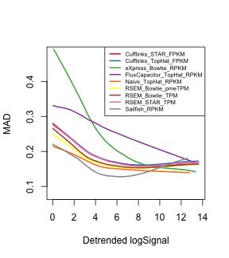

```r
plotMAD(dat1)
## One number statistics: MAD
##       Cufflinks_STAR_FPKM     Cufflinks_TopHat_FPKM
##                     0.265                     0.268
##       eXpress_Bowtie_RPKM FluxCapacitor_TopHat_RPKM
##                     0.357                     0.386
##         Naive_TopHat_RPKM        RSEM_Bowtie_pmeTPM
##                     0.230                     0.243
##           RSEM_Bowtie_TPM             RSEM_STAR_TPM
##                     0.249                     0.265
##             Sailfish_RPKM
##                     0.208
```

Detrended signals shown in the plot are actually the signals with the same scales as Cufflinks pipelines, as we selected `unitReference` as signals from Cufflinks. In this case, FPKM by Cufflinks.

## Specificity on non-expressed features

The proportions of non-expressed features is another important statistics. However, two types of non-expressed features should be analyzed separately:

### Features expressed in one technical replicate but not the other.

The reverse accumulated proportions of such either-or expressed features are plotted stratified by the detrended signals as described previously. Basically, a lower curve indicates higher specificity on these features.

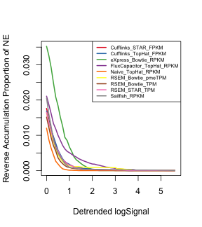

```r
nonexpress <- plotNE(dat1)
```

### Features expressed in neither replicates, and others.

Here, proportions of both expressed, both non-expressed and either-or expressed features are list as a table.

```r
nonexpress
```

```
##                             pEE   pNE   pNN
## Cufflinks_STAR_FPKM       0.524 0.018 0.458
## Cufflinks_TopHat_FPKM     0.523 0.017 0.460
## eXpress_Bowtie_RPKM       0.516 0.035 0.449
## FluxCapacitor_TopHat_RPKM 0.516 0.022 0.462
## Naive_TopHat_RPKM         0.552 0.012 0.436
## RSEM_Bowtie_pmeTPM        0.538 0.017 0.445
## RSEM_Bowtie_TPM           0.530 0.015 0.455
## RSEM_STAR_TPM             0.522 0.017 0.461
## Sailfish_RPKM             0.564 0.021 0.415
```

## Specificity in differential analysis

We calculate the fold change of features between two different cell-lines and compare the fold change concordance between two technical replicates. A strategy that summarizes the overlapped proportions among top differential expressed features is used, as we described before[@irizarry].

```
##       Cufflinks_STAR_FPKM     Cufflinks_TopHat_FPKM
##                 0.7079365                 0.7046154
##       eXpress_Bowtie_RPKM FluxCapacitor_TopHat_RPKM
##                 0.6067797                 0.5846154
##         Naive_TopHat_RPKM        RSEM_Bowtie_pmeTPM
##                 0.7545455                 0.7351351
##           RSEM_Bowtie_TPM             RSEM_STAR_TPM
##                 0.7300000                 0.6941176
##             Sailfish_RPKM
##                 0.7236364
```

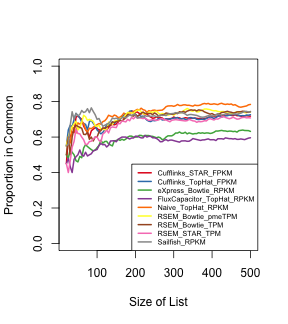

```r
dat2 <- matrixFilter(encodeCells$k562,encodeCells$repInfo,
    evaluationFeature,calibrationFeature,unitReference)
plotCAT(dat1,dat2)
```

Basically higher curve indicates better specificity. `plotCAT` also provides a one number summary of such specificity, which is the median of all overlap proportions plotted. In addition, constant is allowed for a more robust estimation of fold change.

```r
plotCAT(dat1,dat2,constant=1)
```

Or, \(y/0=inf\) with \(y>0\) can be considered into fold changes by comparing \(y\) only.

```r
plotCAT(dat1,dat2,infinity=TRUE)
```

## Sensitivity in differential analysis

There are other platforms provide the same quantifications such as microarray. We thus compare differential analysis of RNA-seq and other technology to evaluate sensitivity of pipelines. We have documented an object `arrayFC` which has been estimated from microarray technology[@ernst]. We don't document the steps how we calculated microarray fold change here, since it is beyond the scope of this vignette.

```
##       Cufflinks_STAR_FPKM     Cufflinks_TopHat_FPKM
##                 0.5565217                 0.5592593
##       eXpress_Bowtie_RPKM FluxCapacitor_TopHat_RPKM
##                 0.4083333                 0.5370370
##         Naive_TopHat_RPKM        RSEM_Bowtie_pmeTPM
##                 0.5166667                 0.5500000
##           RSEM_Bowtie_TPM             RSEM_STAR_TPM
##                 0.5444444                 0.5480000
##             Sailfish_RPKM
##                 0.5391304
```

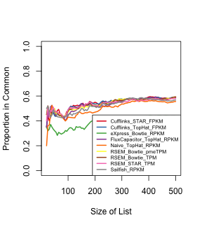

```r
genes <- encodeCells$genemeta[encodeCells$genemeta$type == "protein_coding",1]
otherFC <- encodeCells$arrayFC[match(genes,names(encodeCells$arrayFC))]
plotCAT(dat2,dat1,constant=1,otherFC=otherFC)
```

By comparing with microarray differential analysis, CAT plots will be plotted as higher curve indicates better sensitivity.